# Hydrological coupling open-water - groundwater

# 1 Introduction

During the lectures and first part of the practical on Coupling and Scale you were introduced in temporal (dynamical) aspects of coupling different linear reservoirs.

You were introduced in setting up a system (set of equations) of coupled reservoirs;
$$\frac{\partial
S}{\partial t}= A_sS(t)+B_s\,\;\; S(0)=S_{init}$$

With a matrix style approach, $A_s$ contains the constants of the reservoir outlet ($T_{res}$) and $B_s$ are the external fluxes to the reservoirs. The $S(0)$ are the initial states, which is the product of the area of the reservoir times the head in the reservoir.

With this, since these are linear equations, you applied linear algebra using `calcanalytical()` to get the real solution and `calcexplresult()` and `calcimplresult()` to calculate numerical approximations of the real solutions.

One of the assignments was to create a system of coupled linear reservoirs mimicking the coupling between open water and groundwater;

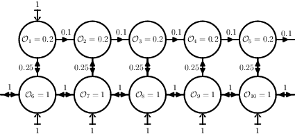

open water - groundwater coupling with linear reservoirs

Here we are going to implement a more physical interaction between a groundwater model and a open water model.

The groundwater is based on the Darcy equation: $Q_{gw}=-KD\frac{\partial H}{\partial{x},y}$ and a (stationary) water balance; $Q_{in}+Q_{out}+Q_{ext}=0$

Open water is simulated with the Manning equation: $Q_{ow}= \frac{1}{n}\sqrt{S_o}AR^{2/3}$ .

When assuming a rectangular profile, this can be rewritten to calculate the water depth directly with $d=\left (\frac{Qn}{w\sqrt S_o}\right )^{3/5}$

Moreover, this coupling does not focus on temporal aspect, so not on “$\Delta t$” and internal time scales, but considers coupling of spatial scales, in this case the interaction between open water flow and groundwater flow under *steady state* conditions.

## 1.1 Learning goals

- Getting acquainted with basic groundwater flow equation setup in a spreadsheet environment
- Getting acquainted with a simple approximation of approximating open water flow with Manning’s equation
- Understand the complexity of coupling different spatial flow domains; groundwater flow and open water flow
- Analyse the impact of the properties of both domains on the solution

# 2 Groundwater model

The groundwater which will be used here is identical to the one you maybe used during the modeling practical of Hydrogeology.

This model is based on a plan view (X-Y) one model layer (aquifer) stationary flow systems and is ready for use but a brief description of the workings of the model will be described here.

The general water balance equation mentioned in the introduction can simply be rewritten to a balance describing fluxes coming from all wind directions:

$$Q_W + Q_N + Q_E + Q_S +
Q_{ext}=0$$

Inserting Darcy’s equation into this water balance and rearranging for dimensions/transmissivities results in:

$$W_{coef}(H_W-H_C)+ N_{coef}(H_N - H_C)+
E_{coef}(H_E - H_C) + S_{coef}(H_S - H_C)+Q_{ext} = 0$$

The Western coefficient $W_{coef}$ stands for:

$$1/2\left ( KD_{NW}\frac{L_N}{L_S} +
KD_{SW}\frac{L_S}{L_W}\right )$$

The “$L$” stands for the width or height of the involved grid cells.

The other coefficients have similar equations but orientation of flow is then rotated 90 degrees. So the western and eastern fluxes are “horizontal” or “left right” fluxes, the northern and southern fluxes are “vertical” of “top bottom” fluxes.

The combination of both the water balance and the fluxes from the four wind directions results in a general equation to solve for the Head at the current node; $H_C$:

$$H_C=\frac{H_W W_{coef}+H_N N_{coef}+H_E
E_{coef}+H_S
S_{coef}+Q_{ext}}{W_{coef}+N_{coef}+E_{coef}+S_{coef}}$$

This way the model is flexible in defining different grid dimensions for individual rows and columns (a structured grid) and the assignment of different transmissivities to each grid cell.

The currrent setup of the groundwater model is based on a domain of 1000m in length (West /East orientation) and 100m in width (North/South orientation):

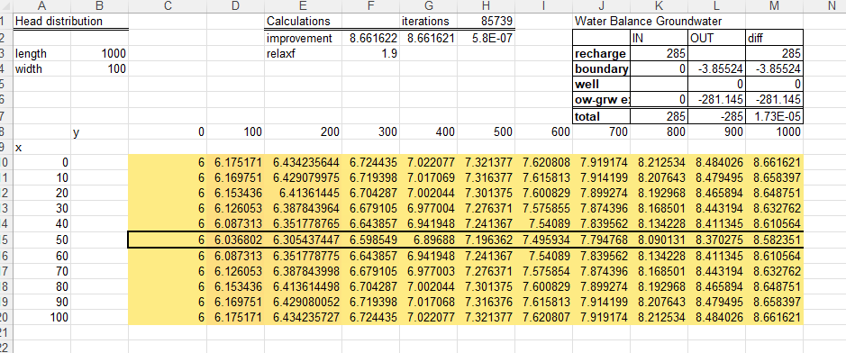

Basic groundwater model implemented in a spreadsheet

Main items shown in the above clip are:

- Head distribution, the calculated heads at the center of each grid cell 11 x 11 (the yellow colored field)
- Water balance groundwater, visible are recharge, boundary fluxes over the prescribed head at the left boundary (located column C), a well (if active) and the exchange of groundwater/surface water of an open water course located here in row 15.
- Convergence of the solution (columns E till H, first row)
- `relaxf` is a relaxation factor to speed up the head calculations. More about this later.

At the row (15) half way of the groundwater model, an open water course will be implemented.

## 2.1 Using the groundwater model

### 2.1.1 Adjusting hydrological properties and boundary conditions

Open the groundwater model “Mesh_Model_XY.xlsx” in Excel.

Adjustable tab sheets:

- H: Assign/Adjust Dirichlet boundary conditions to the model by simply assigning a value (of the head) to that cell/node replacing the formula. If a Dirichlet boundary condition should be replaced by a “H_c” formula simply copy the formula from the neighbour, except for the nodes where the open water course resides (row 15)
- kd: Assign/Adjust freely the transmissivity in the domain of the model
- qext: The external recharge. Here you can adjust the areal precipitation rate in **C3**. Optionally you may add a extraction well. Simply use the lable `well` to “add” this fluxrate ($m^3/d$) to the cell/node like :

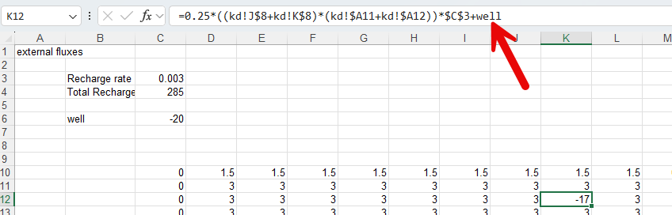

Adding a well to the groundwater model

Do not forget to assign the fluxrate of the well in cell **C6**. Note that a positive rate means an **addition** of that rate to the model.

### 2.1.2 Running the model

The model calculates the final heads (and later water depths of the open water course) using an iteration scheme. It basically means that the calculations, adjusting heads at the nodes, are repeated many times improving the solution (i.e. the final heads) step by step. At a certain moment these improvements are very small, making that the water balance shows only very small errors/misfits (the `diff` in column M) in the water balance that we can say the model is solved and the approximation of the set of equations is satisfactory.

To set Excel into “Iteration mode” look at the clip below and do the following;

- 1: Be sure to set iteration to manual to have full control
- 2: You may chose to Recalculate while saving but I would say NO
- 3: Be sure to check the “iterative calculation” box. Set the “Maximum iteration” to 1 for now to have full control over the iterations and the final results

With this you simply need to press the `F9` key on top of your key board:

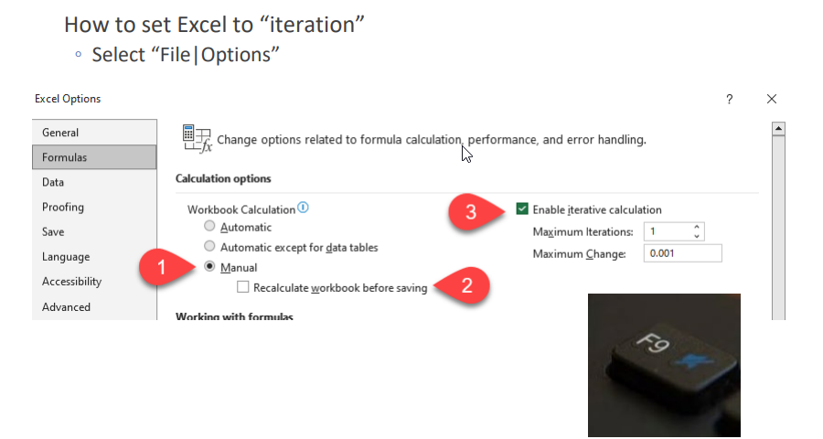

Settings for iteration mode for full control

First assignment:

Play around with the groundwater model by adjusting for example:

- boundary condition
- `kd` and or `qext`
- adding a `well`

Some examples to get acquainted with this model:

Set the Dirichlet boundary condition (column **C** ) to another value Run the model (by pressing/holding down the `<F9>` key till the `diff`, cell **M7** is small (1E-05 or less). If all seems to work fine in the model, you can increase the number of iterations per `<F9>` press, see the “Maximum iterations” field of the previous clip.

or Adjust the transmissivity of the whole of only part of the domain. Run the model till the `diff`, cell **M7** is small (1E-05 or less)

or add an extraction or injection well in the domain. Assign a extraction/injection rate in cell **C6** of the `q_ext` tab.

# 3 Open water flow

Hydraulics or open water flow can be simulated with the St. Venant equations, these require specific (complicated) ways of solutions and can be found in computer programs like Sobek, Delft3D and such. If one is not interested in the full details of open water flow (flow along bridges heads, through culverts) one can simplify these equations. If one is interested in the dynamics (so time) of the open water flow, one may want to simulate this with a kinematic wave approximation. If one is interested in more steady state water depths one may opt for the diffusive wave approximation. The latter will be reviewed in detail in another lecture.

For now, we will equilibrium flow based on the Manning’s equation. The only driving force for open water flow is the bed slope of the open water course:

$$Q_{ow}=
\frac{1}{n}\sqrt{S_o}AR^{2/3}$$

Where:

$n$ : friction coefficient; roughness of the walls of the open water course, vegetation..($\mathrm{sm^{-1/3}}$

$S_o$ : bed slope ($\mathrm{m/m}$)

$A$: cross sectional area $\mathrm{m^2}$

$R$: hydraulic radius ($\mathrm{m}$

If one assumes a rectangular shaped course where the width of the open water coarse is much larger than the water depths:

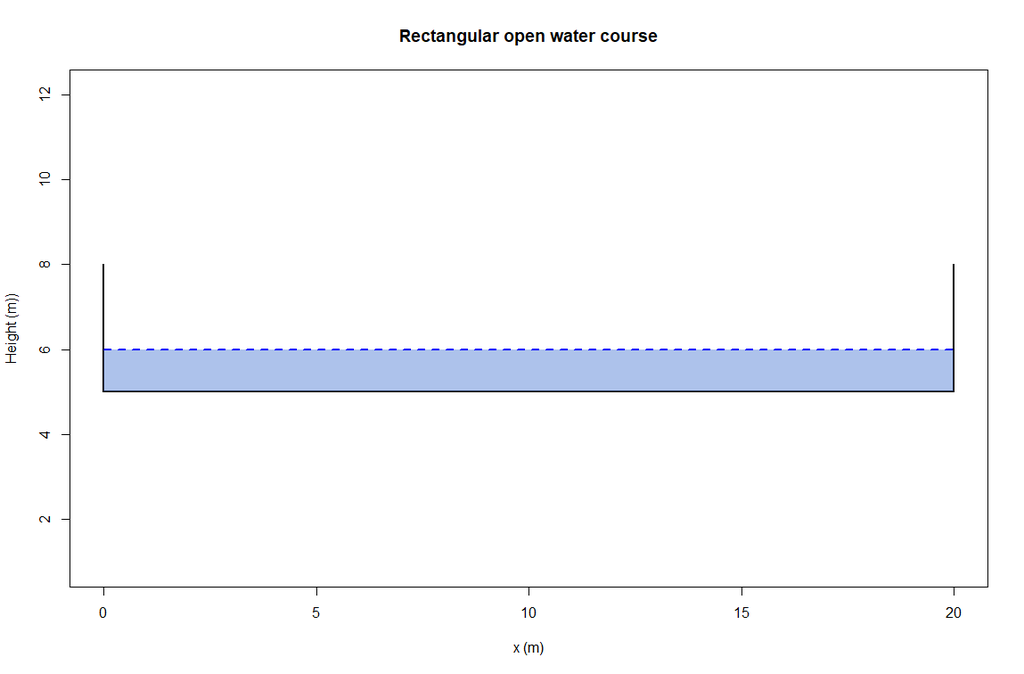

rectangular open water course

With this, one can directly derive the water depth from the aforementioned equation:
$$d=\left
(\frac{Qn}{w\sqrt S_o}\right )^{3/5}$$

## 3.1 Implementing open water flow

Implementing a fully coupled system between open water and groundwater will be carried out in a few steps;

1. adding dimensions and hydraulic properties to the model
2. calculating water depth in the open water course based on equilibrium
3. adding precipitation to the influx of the open water course
4. calculating the open water level w.r.t. M.S.L.
5. calculating the exchange flux between open water and groundwater
6. adding the exchange flux to the influx of the open water course

### 3.1.1 Adding dimensions and hydraulic properties to the model

The dimensions and hydraulic properties which need to be added to the model are:

- the width, the length of the course in each cell
- the river bed resistance, Manning’s roughness coefficient
- the bottom slope and from that the bottom elevation of the open water course

Add these items in the spreadsheet (H-tab) as shown in the following clip;

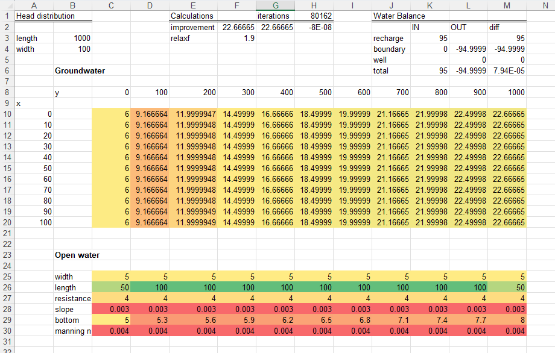

Adding open water dimensions and hydraulic properties

Set the width to 5 m (**C25**) and copy this value up to **M25**

The length of the open water course can be calculated by the cell sizes located in the `kd` tab sheet. Add the following formula cell **C26**: `(kd!b8 + kd!c8)/2` and copy this until cell **M26**

Set the riverbed resistance to 4 d (**C27**) and copy this value up to **M27**

Do the same for the bed slope, 0.003 (m/m) and Mannings roughness coefficient `n` 0.004 (ms^-1/3)

Set the bottom elevation of cell **C29** to 5 m. The bottom elevation of following cell **D29** can be calculated with: `C29+(D8 - C8)*D28` . Copy this formula up to **M29**

### 3.1.2 Calculating water depth in the open water course based on equilibrium

At this stage all parameters are known to calculate the water depth except for the influx at the east end of the open water course.

Start with an influx of 69120 $\mathrm{m^3/d}$ , put this in cell **N36**. Put `=N36` in cell **M36**, referring to the upstream influx. Copy this from **M36** till **C36**.

Open water flow is determined by flux rates defined in units of $\mathrm{m^3/s}$, the influx need to divided by the time unit: 86400. Calculate this in row 37 as shown in the clip below, so `C36/86400` in cell **C37** and copy this till **N37**

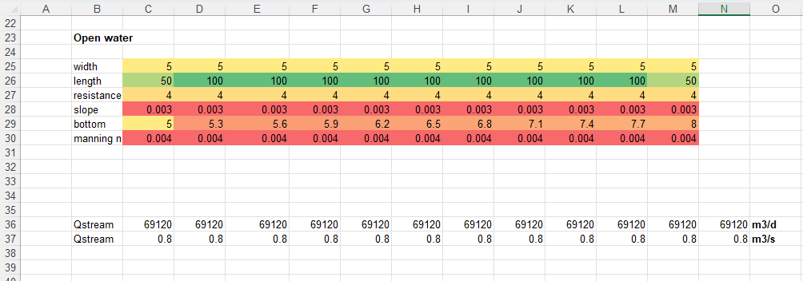

Adding influx rate to the model

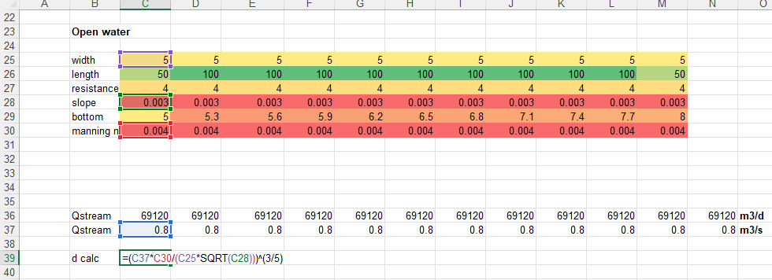

Calculation of the water depth

Copy this formula up till **M39**.

### 3.1.3 Adding precipitation to the influx of the open water course

Precipitation which falls on the open water course can now be added to the flux rate. The total amount can simply be calculated by multiplying the area of the open water course, i.e. `width * length * qext!$C$3`

Calculate the precipitation flux for each cell and assign this to row 33. Make sure the you use the $ signs to have an absolute reference to the recharge rate as depicted above.

Add this recharge rate to the stream flux of each cell as shown in the clip below:

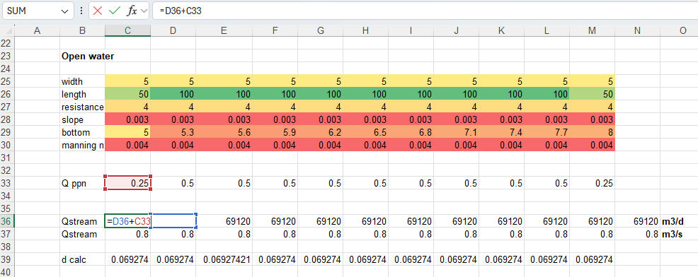

Your sheet should look like the clip below now;

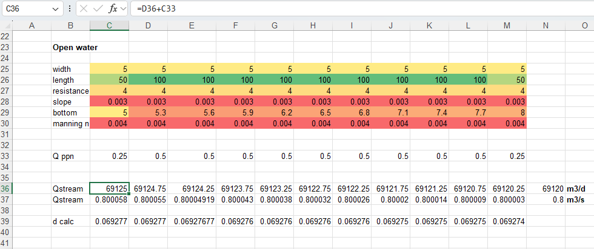

Recharge added to open water flux rate

Note the small impact on the newly calculated water depth. Not that strange, precipitation is only a small fraction of the total flux rate

### 3.1.4 Calculating the open water level w.r.t. M.S.L.

The calculated open water depths in the open water course need to be transformed into open water levels with respect to the mean sea level. This way the exchanges flux can be calculated based on pressure differences, as heads with similar reference.

Calculate the open water levels `H_ow` in row **40** by adding the water depth in row **39** to the bottom elevation located in row **29**.

# 4 Coupling open water to groundwater

## 4.1 Calculating the exchange flux between open water and groundwater

The exchange flux between open water and groundwater is pressure based, expressed as hydraulic heads between open water and groundwater (both at a reference level, Mean Sea Level (M.S.L.). The flux encounters a resistance for flow which depends on the local hydraulic conductivity $K\; (\mathrm{m/d})$ and the thickness of the riverbed, expressed as a resistance:

$$C=\frac{d}{K}$$

Where

$d$ : thickness of the river bed (m)

$C$ : river bed resistance (d)

The exchange flux is now calculated by:

$$Q_{exch}= l\,w\,\frac{H_{ow}-H_{gw}}{C}
\;\;[\mathrm{m^3/d} ]$$

With:

$lw$: length times width of the course in the cell [$\mathrm{m^2}$]

$H_{ow}$ : Head open water [m]

$H_{gw}$ : Head groundwater [m]

This exchange flux is from the groundwater perspective. A gain in a flux for the open water course is a loss of exchange flux to the groundwater system. So in case $H_{ow}$ is higher than $H_{gw}$ , water will infiltrate into the groundwater.

## 4.2 Adding exchange flux to groundwater formula

As described in the introduction, calculation of the groundwater heads at each node/cell, the following formula is applied:

$$H_C=\frac{H_W W_{coef}+H_N N_{coef}+H_E
E_{coef}+H_S S_{coef}+Q_{ext}}{W_{coef}+N_{coef}+E_{coef}+S_{coef}}$$

Adding the exchange flux to this formula means rewriting the exchange flux equation to the following, containing explicit terms for the aquifer head and the open water head:

$$Q_{exch}=
l\,w\,\frac{H_{ow}-H_{gw}}{C}\rightarrow \frac{lw}{C}H_{ow}
-\frac{lw}{C}H_{gw}$$

Adding both (separate) terms to the formula results in:

$$H_C=\frac{H_W W_{coef}+H_N N_{coef}+H_E
E_{coef}+H_S
S_{coef}+Q_{ext}+\frac{lw}{C}H_{ow}}{W_{coef}+N_{coef}+E_{coef}+S_{coef}+\frac{lw}{C}}$$

Add this formula to all cells in row 15 where the open water course is located.

Since the current Dirichlet boundary condition for groundwater is located in column **C** one may omit the exchange flux in cell **C15**.

The following clip illustrates the implementation;

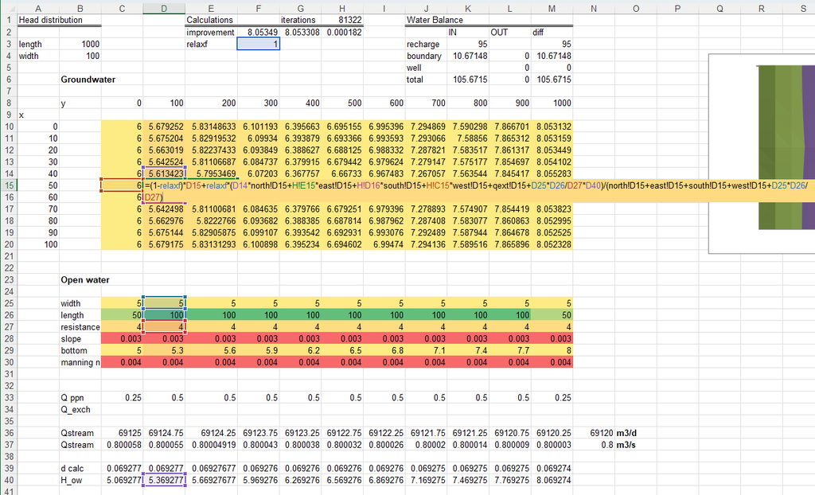

Adding the exchange flux between open water and groundwater

## 4.3 Calculate the exchange flux rate

The exchange flux is directly calculated within the “$H_c$” formula.

To create the exchange between open water and groundwater, working both sides, the exchange flux need to be calculated separately and finally added to the open water flux rate.

Calculate the exchange flux (m3/d) in row **34**.

The model should look like this now;

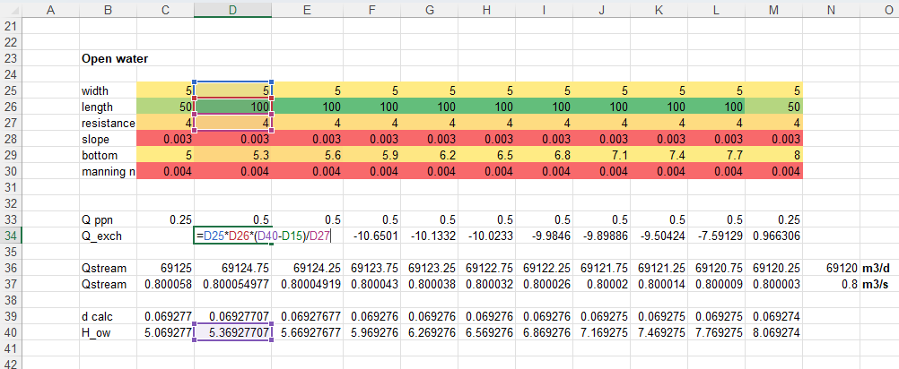

Calculation of the exchange flux

## 4.4 Double coupling open water - groundwater

At this stage the exchange flux is not considered in the calculation of the water depth with Manning’s equation.

The last step is thus simply adding the exchange flux to the open water flux rate;

$Q_{ow}^i=Q_{ow}^{i-1}+Q_{ppn}^i+Q_{exch}^i$

Note the $i^{th}$ index, indicates that the open water flux for for example column **D** is the open water flux of column **E** and the precipitation and exchange flux rate of **D**

Be aware of the sign of the exchange flux

Now add all open water fluxes to row **36**

If all went all right you should now have a double coupled model in which the exchange flux between open water and groundwater is now activated. The model should look like;

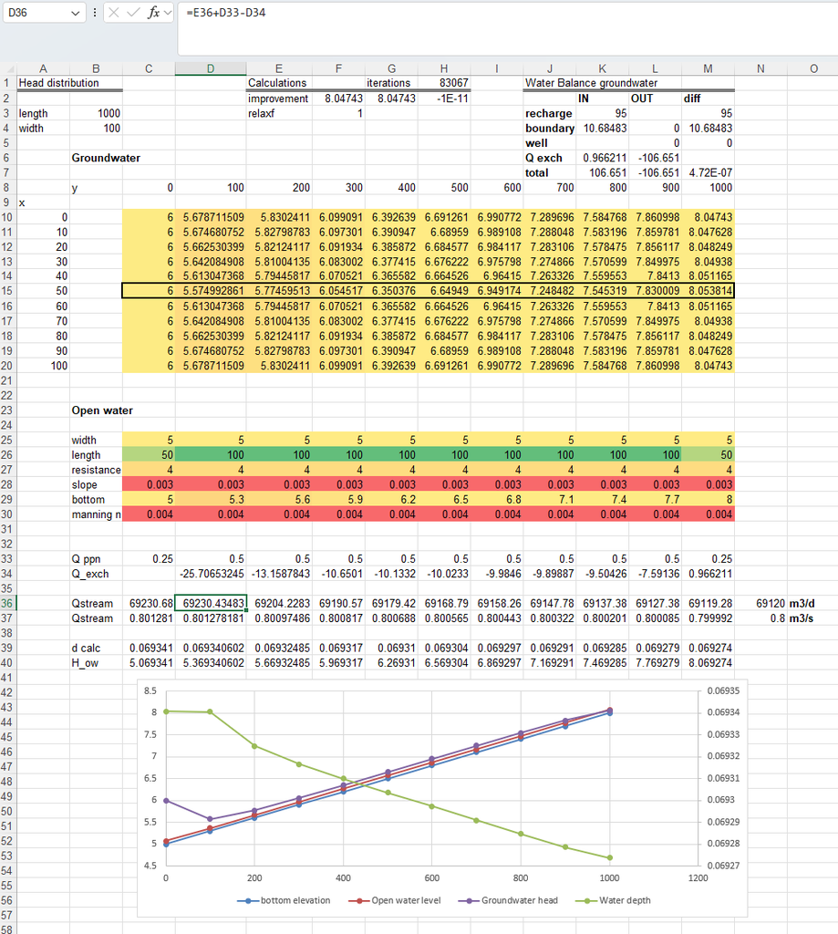

The final model including a coupling of open water and groundwater

Also note the graph indicating the bottom elevation, water depth, open water level and the groundwater level. Creating such a plot gives a clear view on the results of the model

# 5 Simulation experiments

To see the effect of different measures and hydrological properties on the flow pattern in both domains and how the interaction responds, many conditions could be considered.

Here we are looking at only a few, hopefully interesting, conditions, both from the groundwater and the open water perspective. Chose a few of the following adjustments to the coupled model and analyse the impact of:

1. the manning’s roughness coefficient
2. the bed slope of the open water course
3. the width of the open water course
4. the river bed resistance
5. the hydraulic conducitivity (transmissivity)
6. the local well close to the open water course
7. other Dirichlet boundary condition

## 5.1 Comparing results

To compare the impact of the adjustments, it’s convenient to plot both situations and/or look at the differences.

Start with a reference situation. Use the initial set up or increase the influx of the open water course (cell **N36**) to e.g. 5 m3/s and also adjust $n$ to e.g. 0.025 sm^-1/3

Add a new tab sheet to the model

- copy the currrent groundwater heads (**C10:M20**) AS VALUES to the new tab sheet at e.g. at **P10.** These are now the reference groundwater heads
- at cell **C10** in the new sheet, subtract the current groundwater head from the reference groundwater heads: **H!C10 - P10**
- Copy this formula up to **M20**
- Do a similar approach with Open water head, and Q_exch
- Create plots of the reference and current situation or plot the differences of the reference and current situation